# Population Growth and CO2 Emissions

Emmanuel NIYONKURU - 20252MBI043

11/04/2026

# 1 Introduction

This project explores how population size and growth relate to carbon dioxide (CO2) emissions. It describes the supplied country-level population dataset, projects 2030 population using the specified exponential formula, visualizes population and emissions trends, and compares population with per-capita CO2 emissions.

# 2 Data preparation and exploratory analysis

The population file contains 234 rows and 17 columns. The CO2 file contains 215 rows and 35 columns before removing its duplicate 2019 column. Population years are available at decadal or selected intervals; CO2 emissions cover each year from 1990 through 2019. The CO2 measure is **metric tons per capita**, not total national emissions.

## 2.1 Variable names and structure

```r
names(population_raw)
```

```
##  [1] "Rank"                        "CCA3"
##  [3] "Country/Territory"           "Capital"
##  [5] "Continent"                   "2022 Population"
##  [7] "2020 Population"             "2015 Population"
##  [9] "2010 Population"             "2000 Population"
## [11] "1990 Population"             "1980 Population"
## [13] "1970 Population"             "Area (km²)"
## [15] "Density (per km²)"           "Growth Rate"
## [17] "World Population Percentage"
```

```r
str(population_raw)
```

```
## 'data.frame':    234 obs. of  17 variables:
##  $ Rank                       : int  36 138 34 213 203 42 224 201 33 140 ...
##  $ CCA3                       : chr  "AFG" "ALB" "DZA" "ASM" ...
##  $ Country/Territory          : chr  "Afghanistan" "Albania" "Algeria" "American Samoa" ...
##  $ Capital                    : chr  "Kabul" "Tirana" "Algiers" "Pago Pago" ...
##  $ Continent                  : chr  "Asia" "Europe" "Africa" "Oceania" ...
##  $ 2022 Population            : int  41128771 2842321 44903225 44273 79824 35588987 15857 93763 45510318 2780469 ...
##  $ 2020 Population            : int  38972230 2866849 43451666 46189 77700 33428485 15585 92664 45036032 2805608 ...
##  $ 2015 Population            : int  33753499 2882481 39543154 51368 71746 28127721 14525 89941 43257065 2878595 ...
##  $ 2010 Population            : int  28189672 2913399 35856344 54849 71519 23364185 13172 85695 41100123 2946293 ...
##  $ 2000 Population            : int  19542982 3182021 30774621 58230 66097 16394062 11047 75055 37070774 3168523 ...
##  $ 1990 Population            : int  10694796 3295066 25518074 47818 53569 11828638 8316 63328 32637657 3556539 ...
##  $ 1980 Population            : int  12486631 2941651 18739378 32886 35611 8330047 6560 64888 28024803 3135123 ...
##  $ 1970 Population            : int  10752971 2324731 13795915 27075 19860 6029700 6283 64516 23842803 2534377 ...
##  $ Area (km²)                 : int  652230 28748 2381741 199 468 1246700 91 442 2780400 29743 ...
##  $ Density (per km²)          : num  63.1 98.9 18.9 222.5 170.6 ...
##  $ Growth Rate                : num  1.026 0.996 1.016 0.983 1.01 ...
##  $ World Population Percentage: num  0.52 0.04 0.56 0 0 0.45 0 0 0.57 0.03 ...
```

```r
dim(population_raw)
```

```
## [1] 234  17
```

## 2.2 First five and last ten observations

```r
head(population_raw, 5)
```

```
##   Rank CCA3 Country/Territory          Capital Continent 2022 Population
## 1   36  AFG       Afghanistan            Kabul      Asia        41128771
## 2  138  ALB           Albania           Tirana    Europe         2842321
## 3   34  DZA           Algeria          Algiers    Africa        44903225
## 4  213  ASM    American Samoa        Pago Pago   Oceania           44273
## 5  203  AND           Andorra Andorra la Vella    Europe           79824
##   2020 Population 2015 Population 2010 Population 2000 Population
## 1        38972230        33753499        28189672        19542982
## 2         2866849         2882481         2913399         3182021
## 3        43451666        39543154        35856344        30774621
## 4           46189           51368           54849           58230
## 5           77700           71746           71519           66097
##   1990 Population 1980 Population 1970 Population Area (km²) Density (per km²)
## 1        10694796        12486631        10752971     652230           63.0587
## 2         3295066         2941651         2324731      28748           98.8702
## 3        25518074        18739378        13795915    2381741           18.8531
## 4           47818           32886           27075        199          222.4774
## 5           53569           35611           19860        468          170.5641
##   Growth Rate World Population Percentage
## 1      1.0257                        0.52
## 2      0.9957                        0.04
## 3      1.0164                        0.56
## 4      0.9831                        0.00
## 5      1.0100                        0.00
```

```r
tail(population_raw, 10)
```

```
##     Rank CCA3 Country/Territory      Capital     Continent 2022 Population
## 225   43  UZB        Uzbekistan     Tashkent          Asia        34627652
## 226  181  VUT           Vanuatu    Port-Vila       Oceania          326740
## 227  234  VAT      Vatican City Vatican City        Europe             510
## 228   51  VEN         Venezuela      Caracas South America        28301696
## 229   16  VNM           Vietnam        Hanoi          Asia        98186856
## 230  226  WLF Wallis and Futuna     Mata-Utu       Oceania           11572
## 231  172  ESH    Western Sahara     El Aaiún        Africa          575986
## 232   46  YEM             Yemen        Sanaa          Asia        33696614
## 233   63  ZMB            Zambia       Lusaka        Africa        20017675
## 234   74  ZWE          Zimbabwe       Harare        Africa        16320537
##     2020 Population 2015 Population 2010 Population 2000 Population
## 225        33526656        30949417        28614227        24925554
## 226          311685          276438          245453          192074
## 227             520             564             596             651
```

[output cut: 29 more lines]

## 2.3 Duplicate rows and missing values

There are 0 duplicate population rows. No duplicate rows are removed unless present. Missing values by population column are shown below.

```r
data.frame(
  variable = names(population_raw),
  missing_values = colSums(is.na(population_raw))
)
```

```
##                                                variable missing_values
## Rank                                               Rank              0
## CCA3                                               CCA3              0
## Country/Territory                     Country/Territory              0
## Capital                                         Capital              0
## Continent                                     Continent              0
## 2022 Population                         2022 Population              0
## 2020 Population                         2020 Population              0
## 2015 Population                         2015 Population              0
## 2010 Population                         2010 Population              0
## 2000 Population                         2000 Population              0
## 1990 Population                         1990 Population              0
## 1980 Population                         1980 Population              0
## 1970 Population                         1970 Population              0
## Area (km²)                                   Area (km²)              0
## Density (per km²)                     Density (per km²)              0
## Growth Rate                                 Growth Rate              0
## World Population Percentage World Population Percentage              0
```

The population file has no missing observations, so no imputation or deletion is needed. The CO2 file has 24 missing 2019 emission values; missing CO2 observations are excluded from analyses requiring that year rather than imputed.

## 2.4 Outlier screening

```r
kable(outlier_summary, digits = 3,
      caption = "IQR-based outlier counts in selected population variables")
```

IQR-based outlier counts in selected population variables

| variable | lower_bound | upper_bound | outlier_count |
| --- | --- | --- | --- |
| rank | -115.500 | 350.500 | 0 |
| pop_2022 | -32665410.875 | 55561654.125 | 25 |
| pop_2020 | -31133758.000 | 52997022.000 | 26 |
| pop_2015 | -28584590.625 | 48720120.375 | 27 |
| pop_2010 | -27756478.750 | 47309195.250 | 26 |
| pop_2000 | -22825346.500 | 38914889.500 | 29 |
| pop_1990 | -17143557.125 | 29276903.875 | 31 |
| pop_1980 | -14165045.000 | 24220713.000 | 32 |
| pop_1970 | -12836001.000 | 21809327.000 | 29 |
| area_km2 | -639013.625 | 1072089.375 | 28 |
| density | -262.355 | 539.706 | 22 |
| growth_factor | 0.979 | 1.040 | 3 |
| world_pct | -0.395 | 0.685 | 25 |

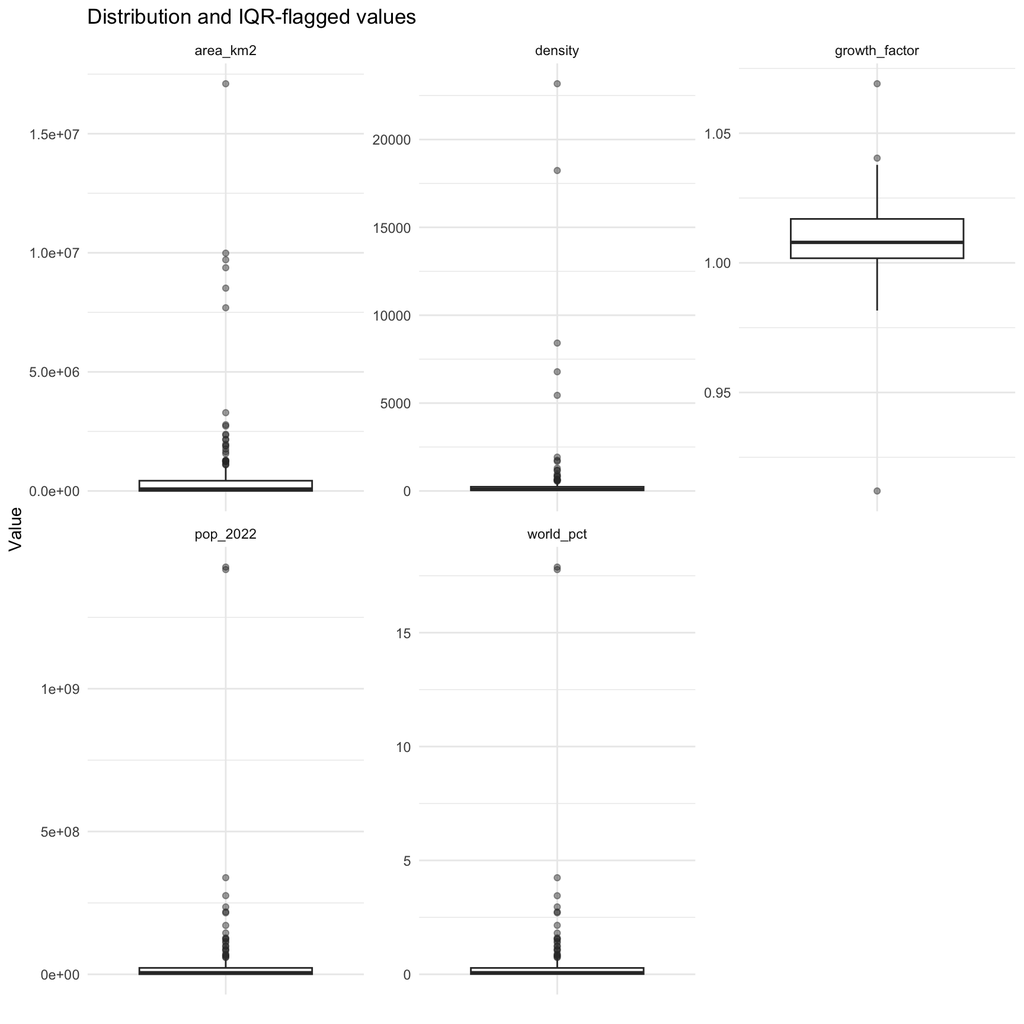

```r
outlier_long <- population |>
  select(country_name, pop_2022, area_km2, density, growth_factor, world_pct) |>
  pivot_longer(-country_name, names_to = "variable", values_to = "value")
ggplot(outlier_long, aes(x = "", y = value)) +
  geom_boxplot(outlier.alpha = 0.45) +
  facet_wrap(~ variable, scales = "free_y", ncol = 3) +
  labs(x = NULL, y = "Value",
       title = "Distribution and IQR-flagged values") +
  theme_minimal()
```

# 3 Population projection to 2030

The supplied `Growth Rate` is stored as a multiplicative annual factor (for example, 1.01 represents approximately 1% growth). I therefore use the annual decimal rate $r = \text{Growth Rate} - 1$ and `t = 8` years in `N[t] = P * exp(r * t)`, with 2022 population as `P`. This assumes a constant rate through 2030 and is an illustrative projection, not an official forecast.

```r
top10 |>
  select(country_name, pop_2022, annual_growth_rate, pop_2030) |>
  mutate(across(c(pop_2022, pop_2030), round)) |>
  kable(col.names = c("Country", "2022 population", "Annual rate", "Projected 2030"),
        caption = "Projection for the ten most populous countries")
```

Projection for the ten most populous countries

| Country | 2022 population | Annual rate | Projected 2030 |
| --- | --- | --- | --- |
| China | 1425887337 | 0.0000 | 1425887337 |
| India | 1417173173 | 0.0068 | 1496402904 |
| United States | 338289857 | 0.0038 | 348731782 |
| Indonesia | 275501339 | 0.0064 | 289974355 |
| Pakistan | 235824862 | 0.0191 | 274757645 |
| Nigeria | 218541212 | 0.0241 | 265011868 |
| Brazil | 215313498 | 0.0046 | 223384633 |
| Bangladesh | 171186372 | 0.0108 | 186634630 |
| Russia | 144713314 | -0.0027 | 141621023 |
| Mexico | 127504125 | 0.0063 | 134095029 |

# 4 Population trends

## 4.1 Ten most populous countries in 2022

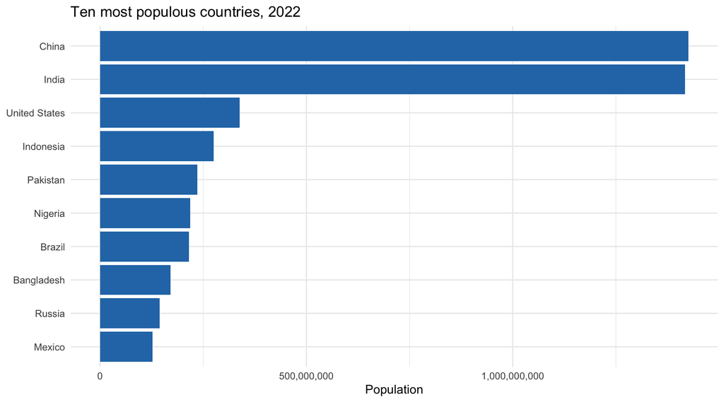

```r
ggplot(top10, aes(x = reorder(country_name, pop_2022), y = pop_2022)) +
  geom_col(fill = "#2878B5") +
  coord_flip() +
  scale_y_continuous(labels = scales::label_comma()) +
  labs(x = NULL, y = "Population",
       title = "Ten most populous countries, 2022") +
  theme_minimal()
```

## 4.2 Available population trend observations, 1990-2022

Population observations are available for 1990, 2000, 2010, 2015, 2020, and 2022; the lines connect these observed years and do not imply annual data.

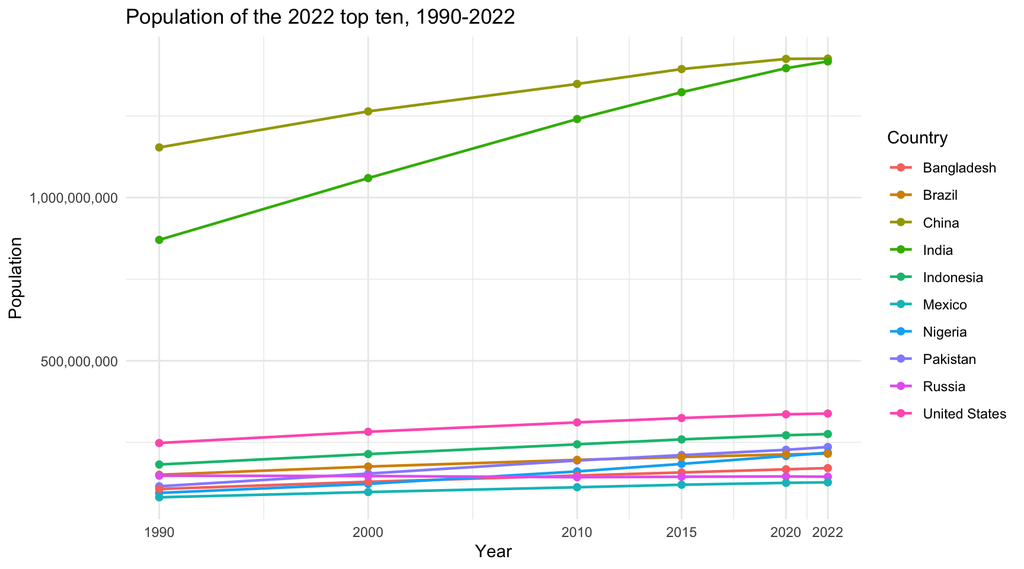

```r
ggplot(top10_trend, aes(x = year, y = population,
                        color = country_name, group = country_name)) +
  geom_line(linewidth = 0.8) +
  geom_point(size = 1.8) +
  scale_y_continuous(labels = scales::label_comma()) +
  scale_x_continuous(breaks = c(1990, 2000, 2010, 2015, 2020, 2022)) +
  labs(x = "Year", y = "Population", color = "Country",
       title = "Population of the 2022 top ten, 1990-2022") +
  theme_minimal()
```

# 5 CO2 emissions trend for the top ten

Country codes are used to harmonize country-name variants (for example, different spellings or official names) before joining on canonical country names. CO2 values are per capita. Missing country-year values remain missing and are omitted from the corresponding line segments.

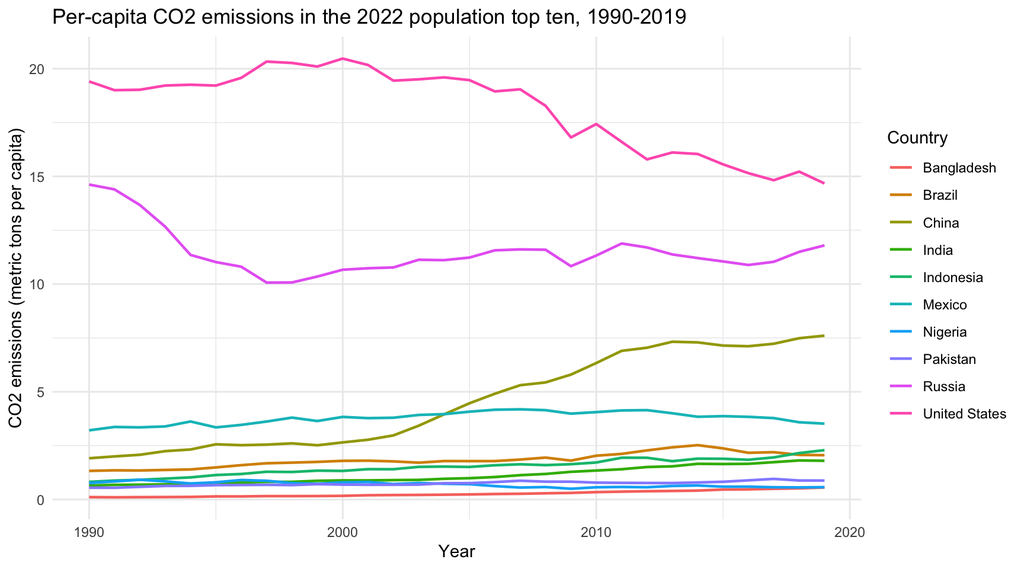

```r
ggplot(top10_co2, aes(x = year, y = co2_per_capita,
                      color = country_name, group = country_name)) +
  geom_line(linewidth = 0.8, na.rm = TRUE) +
  labs(x = "Year", y = "CO2 emissions (metric tons per capita)",
       color = "Country",
       title = "Per-capita CO2 emissions in the 2022 population top ten, 1990-2019") +
  theme_minimal()
```

# 6 Correlation analysis

## 6.1 Population characteristics

The correlations below describe linear association among area, density, annual growth rate, and share of world population. Correlation does not establish causation.

```r
round(correlation_matrix, 3)
```

```
##                    area_km2 density annual_growth_rate world_pct
## area_km2              1.000  -0.063             -0.014     0.453
## density              -0.063   1.000             -0.070    -0.028
## annual_growth_rate   -0.014  -0.070              1.000    -0.021
## world_pct             0.453  -0.028             -0.021     1.000
```

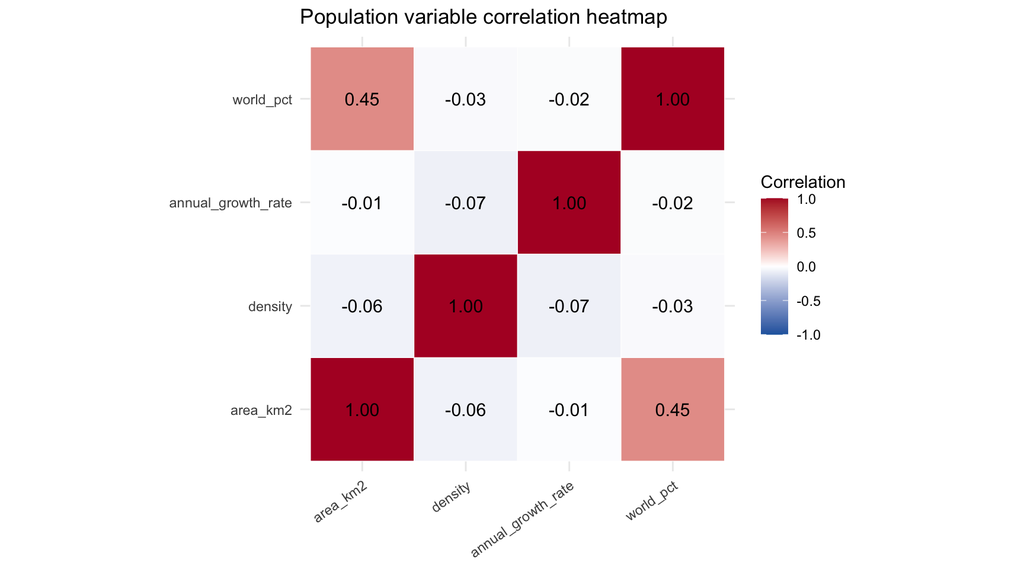

```r
ggplot(correlation_long, aes(variable_x, variable_y, fill = correlation)) +
  geom_tile(color = "white") +
  geom_text(aes(label = sprintf("%.2f", correlation)), size = 4) +
  scale_fill_gradient2(
    low = "#2166AC", mid = "white", high = "#B2182B",
    midpoint = 0, limits = c(-1, 1)
  ) +
  coord_equal() +
  labs(x = NULL, y = NULL, fill = "Correlation",
       title = "Population variable correlation heatmap") +
  theme_minimal() +
  theme(axis.text.x = element_text(angle = 35, hjust = 1))
```

## 6.2 2022 population and 2019 CO2 emissions

The merged analysis includes 191 countries with both 2022 population and non-missing 2019 per-capita emissions. Pearson’s correlation is 0.014 (0.843). The regression below uses log10 population because population is strongly right-skewed; it describes association with per-capita emissions, not total emissions.

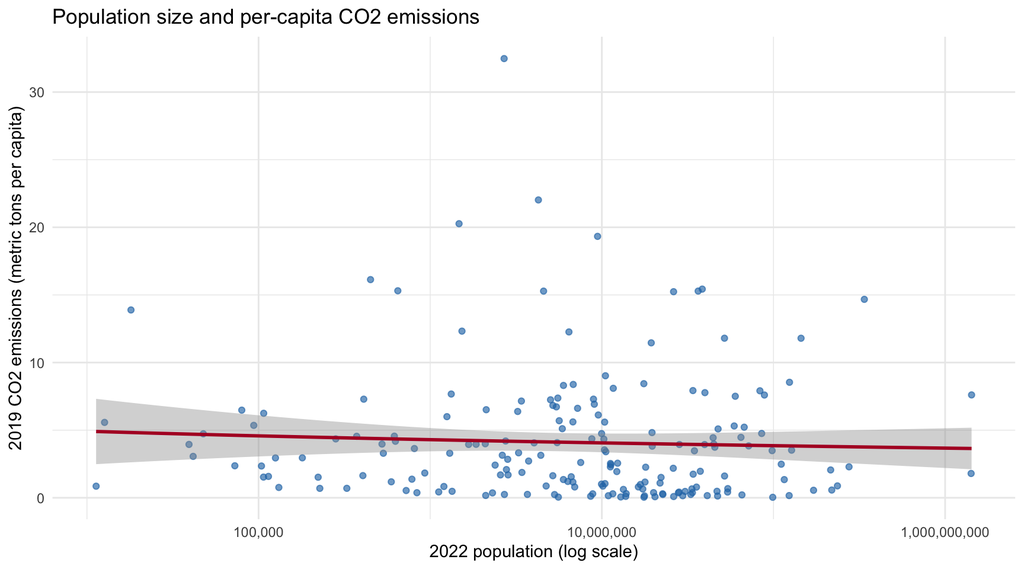

```r
ggplot(merged_complete,
       aes(x = pop_2022, y = co2_2019)) +
  geom_point(alpha = 0.65, color = "#2878B5") +
  geom_smooth(aes(x = pop_2022), method = "lm", se = TRUE,
              formula = y ~ log10(x), color = "#B2182B") +
  scale_x_log10(labels = scales::label_comma()) +
  labs(x = "2022 population (log scale)",
       y = "2019 CO2 emissions (metric tons per capita)",
       title = "Population size and per-capita CO2 emissions") +
  theme_minimal()
```

```r
summary(population_co2_model)
```

```
##
## Call:
## lm(formula = co2_2019 ~ log10(pop_2022), data = merged_complete)
##
## Residuals:
##    Min     1Q Median     3Q    Max
## -4.083 -3.216 -1.492  1.462 28.263
##
## Coefficients:
##                 Estimate Std. Error t value Pr(>|t|)
## (Intercept)       5.7780     2.4914   2.319   0.0215 *
## log10(pop_2022)  -0.2437     0.3616  -0.674   0.5013
## ---
## Signif. codes:  0 '***' 0.001 '**' 0.01 '*' 0.05 '.' 0.1 ' ' 1
##
## Residual standard error: 4.721 on 189 degrees of freedom
## Multiple R-squared:  0.002396,   Adjusted R-squared:  -0.002882
## F-statistic: 0.454 on 1 and 189 DF,  p-value: 0.5013
```

# 7 Comparison by continent

The requested continent comparison sums country-level 2019 per-capita values within each continent. This is an unweighted sum of per-capita indicators; it is **not** a continent’s total CO2 emissions. A population-weighted estimate or total-emissions dataset would be needed to compare total emissions properly.

```r
kable(continent_totals, digits = 2,
      col.names = c("Continent", "Sum of country per-capita values"),
      caption = "2019 CO2 metric tons per capita summed across available countries")
```

2019 CO2 metric tons per capita summed across available countries

| Continent | Sum of country per-capita values |
| --- | --- |
| Asia | 290.55 |
| Europe | 246.67 |
| North America | 96.90 |
| Africa | 63.73 |
| Oceania | 54.78 |
| South America | 33.36 |

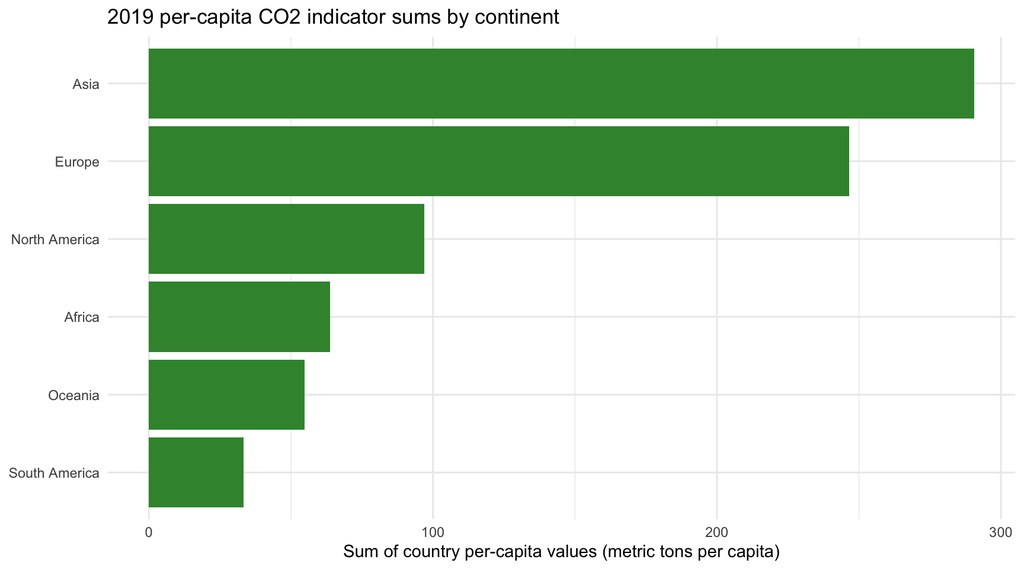

```r
ggplot(continent_totals,
       aes(x = reorder(continent, sum_country_per_capita),
           y = sum_country_per_capita)) +
  geom_col(fill = "#3A923A") +
  coord_flip() +
  labs(x = NULL,
       y = "Sum of country per-capita values (metric tons per capita)",
       title = "2019 per-capita CO2 indicator sums by continent") +
  theme_minimal()
```

In the requested sum, the first continent is **Asia** (290.55). The third is **North America** (96.9) and the last is **South America** (33.36). These values should be interpreted with the per-capita summation caveat above.

# 8 Discussion, recommendations, and conclusion

Population grew substantially in several of the most populous countries, but the exponential projection assumes each country’s 2022 growth rate remains constant. Population size alone is not a measure of per-capita emissions, and the country-level association should not be interpreted as a causal effect. The CO2 dataset also contains missing observations and reports emissions per capita, limiting conclusions about total emissions. Future work should use annual population data, document a forecast model and uncertainty, and obtain total emissions or population-weighted per-capita emissions for fair continent-level comparisons.

This analysis applies data inspection, cleaning, visualization, projection, country matching, and correlation/regression methods. The main lesson is that the meaning and units of a variable matter: summing per-capita values does not produce total emissions.